# Praca Domowa 2 - CNK - liczba unikalnych uzytkownikow (R i Big Data)

Ewa Baranowska

14 marca 2016

#### Przerabialam pliki .log z uzyciem pakietu parallel, starajac sie napisac kolejne kroki jako w miare oddzielone etapy, tak by moc je odtworzyc, bez potrzeby powtarzania poprzednich (tj. kilkukrotnie przerabialam pliki z danymi, tworzylam nowe pliki etc.).

##### Czesc etapow jest czasochlonna, wiec podalam jedynie kod i osiagniety czas, bez wywolywania ich ponownie na uzytek tego raportu.

## Przetwarzanie logow do .csv z kolumnami: month, day, visitor

```r
#zapisuje miejsce z danymi
sciezka_do_danych <- file.path("C:/Users/E540/Desktop/SMAD/R i Big Data/Projekt 1/2013")

#jesli ten folder istnieje (mamy dane) to przechodzimy dalej
if(dir.exists(sciezka_do_danych)){

   czas <- Sys.time() # zapisujemy czas by sprawdzic efektywnosc kodu

   # tworzymy wektor z lista miesiecy (folderow w folderze 2013)
   foldery_mies <- list.dirs(sciezka_do_danych,full.names = F, recursive = F)

   # tworzymy wektor wszystkich folderow w folderach z miesiacami (tj. docelowo wektor nazw urzadzen)
   sciezka_do_miesiac <- character(1)
   urzadzenia <- character(0)

   for(miesiac in foldery_mies){
      # z danego miesiaca wybieram urzadzenia
      sciezka_do_miesiac <- file.path(sciezka_do_danych, miesiac)
      urzadzenia_tmp <- list.dirs(sciezka_do_miesiac, full.names = F, recursive = F)
      # dodaje wszystkie unikalne nazwy do nazw urzadzen
      if(!setequal(urzadzenia, urzadzenia_tmp)){
         urzadzenia <- union(urzadzenia, urzadzenia_tmp)
      }
   }
   # zostawiamy w tym wektorze tylko nazwy typu "cnk...""
   library(stringi)
   urzadzenia_tylko <- as.character(na.omit(stri_extract_first_regex(urzadzenia, pattern = "cnk[\\p{N}\\p{L}]*")))

   # zakladam, ze unikalny uzytkownik to (rok,miesiac,dzien)=data + numer_karty, tj. unikalny użytkownik to taki,
   # który mial jednoczesnie rozna date i numer karty

   #lacze argumenty w forme "01:cnk02a"
   ile_urzadzen <- length(urzadzenia_tylko)

   miesiac_urzadzenie <- data.frame(A = rep(foldery_mies, rep(ile_urzadzen, length(foldery_mies))),
                               B = rep(urzadzenia_tylko,length(foldery_mies)), stringsAsFactors = F)

   miesiac_urzadzenie<- with(miesiac_urzadzenie, paste0(A,":", B))



   # uzywam pakietu parallel do jednoczesnego przetwarzania skryptu na wielu rdzeniach
   library(parallel)

   ile_rdzeni <- detectCores() - 1 # jeden mniej, bym mogla robic cos przy okazji puszczania skryptu
   klaster <-makeCluster(ile_rdzeni)

   # dodajemy zmienne i pakiety, ktore sa "zewnetrzne"
   clusterExport(klaster, c("sciezka_do_danych", "miesiac_urzadzenie"))
   clusterEvalQ(klaster, library(stringi))

   # paralelna wersja lapply
   parLapply(klaster, miesiac_urzadzenie, function(x){

      miesiac <- unlist(stri_split_fixed(x,":"))[1]
      urzadzenie <- unlist(stri_split_fixed(x,":"))[2]

      folder_do_zapisu <- file.path("C:/Users/E540/Desktop/SMAD/R i Big Data/PD2",urzadzenie,miesiac)
      if( !dir.exists(folder_do_zapisu) ){
         dir.create(folder_do_zapisu, recursive = T)
      }

         # w niektorych miesiacach nie ma pewnych maszyn
         sciezka_konkretna <- file.path(sciezka_do_danych, miesiac, urzadzenie, paste(urzadzenie,".log", sep="", collapse = ""))
         if( file.exists(sciezka_konkretna) ){

            # wczytanie danych
            raport <- readLines(sciezka_konkretna)
            # wybor wiersza z numerem visitora
            regex <- paste("([\\p{L}]{3}) ([\\p{N}]{2}| [\\p{N}]{1}) (?:.+) hostname=",urzadzenie,
                           " INFO: APP/cnklib Added visitor (.+) to session (?:.+)", sep="", collape="")

            string <- stri_match_first_regex(raport, pattern = regex)
            string <- string[!is.na(string[,1]),c(2,3,4)] # wybieram tylko niepuste

            # jesli dane urzadzenie mialo jakichs zarejestrowanych uzytkownikow to przetwarzam dalej, jak nie to zapisuje to w
            # pliku z bledami
            if( length(string) > 0 ){
               string <- as.data.frame(string)
               colnames(string) <- c("month", "day", "visitor")
               #zapisuje csv w folderze w PD2/urzadzenie_miesiac.csv
               write.csv(string, file = file.path(folder_do_zapisu,paste(urzadzenie,'_',miesiac,".csv", collapse = "",sep="")),
                         row.names = F)
            }else{
                  uwaga <- paste("Dla urzadzenia", urzadzenie, "w miesiacu", miesiac, "nie ma uzytkownikow")
                  write(uwaga, file = file.path("C:/Users/E540/Desktop/SMAD/R i Big            Data/PD2/brak_uzytkownikow.txt"),  append=T)
                  }

         }


   }

   )


   stopCluster(klaster)

   print(Sys.time() - czas)
}

#Time difference of 12.7919 mins

# UWAGI:
# wyczyscic te pliki z bledami, bo sie nadpisuja
# usuwac w parallel zbedne zmienne na biezaco
# niepotrzebnie tworzylam foldery w urzadzeniach, 01, 02 - i tak mam nazwy odpowiednie plikow
```

## Przetwarzanie uzyskanych .csv do plikow z suma unikalnych uzytkownikow wg urzadzen

```r
czas <- Sys.time()

sciezka_do_tabel <- file.path("C:/Users/E540/Desktop/SMAD/R i Big Data/PD2")
sciezka_zapisu <- file.path(sciezka_do_tabel,"analizy")

if(!dir.exists(sciezka_zapisu)){
   dir.create(sciezka_zapisu, recursive = T)
}else{ # usuwa pliki z folderu przed analiza
   do.call(file.remove, list(list.files(sciezka_zapisu, full.names = T)))
}


library(parallel)

ile_rdzeni <- detectCores() - 1
klaster <-makeCluster(ile_rdzeni)

clusterExport( klaster, c("sciezka_do_tabel","sciezka_zapisu",  "miesiac_urzadzenie") )
clusterEvalQ( klaster, c(library(stringi),library(dplyr)) )

parLapply(klaster, miesiac_urzadzenie, function(x){

   miesiac <- unlist(stri_split_fixed(x,":"))[1]
   urzadzenie <- unlist(stri_split_fixed(x,":"))[2]

   #wczytujemy odpowiedni plik .csv
   sciezka_z_csv <- file.path(sciezka_do_tabel,urzadzenie,miesiac,paste(urzadzenie,"_", miesiac, ".csv", sep=""))

   if(file.exists(sciezka_z_csv)){

      dane <- read.csv(sciezka_z_csv, sep=",", stringsAsFactors = F, header = T)

      dane %>% group_by(month, day, visitor) %>% filter(row_number() == 1) %>% # unikalne jednostki
         group_by(month, day) %>% mutate(count = n()) %>% filter(row_number() == 1) %>%
         select(-visitor) -> policzone_dane #zliczanie wystapien w dniu miesiaca

      # gdzie zapisac raport podsumowujacy dla urzadzenia
      sciezka_raportu <- file.path(sciezka_zapisu,paste(urzadzenie,"_podsumowanie.csv", sep=""))


      # jesli plik nie istnieje to dajemy colnames i nie nadpisujemy (bo nie ma czego)
      if(!file.exists(sciezka_raportu)){

         write.table(policzone_dane, file= sciezka_raportu, sep=",", row.names = F,append=F) #write.csv nie ma opcji append

      }else{

         write.table(policzone_dane, file= sciezka_raportu, sep=",", row.names = F,append=T, col.names = F)


      }

   }

}  )

stopCluster(klaster)

print(Sys.time() - czas)

#Time difference of 28.86868 secs

# robie calosciowy plik z podsumowaniami, zwyklym forem, na podstawie przed chwila uzyskanych plikow .csv

czas <- Sys.time()

library(dplyr)

for(urzadzenie in urzadzenia_tylko){

   sciezka_z_podsumowaniem <- file.path(sciezka_zapisu,paste(urzadzenie,"_podsumowanie.csv", sep=""))

   if(file.exists(sciezka_z_podsumowaniem)){

      dane <- read.csv(sciezka_z_podsumowaniem, sep=",", stringsAsFactors = F, header = T)

      dane %>% mutate(device = urzadzenie) -> policzone_dane #dodajemy kolumne z nazwa urzadzenia

      # jeden plik wyjsciowy
      sciezka_raportu_calosc <- file.path(sciezka_zapisu,paste("calosc_podsumowanie.csv", sep=""))

      if(!file.exists(sciezka_raportu_calosc)){

         write.table(policzone_dane, file= sciezka_raportu_calosc, sep=",", row.names = F,append=F)

      }else{

         write.table(policzone_dane, file= sciezka_raportu_calosc, sep=",", row.names = F,append=T, col.names = F)


      }

   }

}

print(Sys.time() - czas)

#Time difference of 0.4076009 secs

#UWAGI:
# append nadpisuje plik - moga pojawic sie problemy w zapisie (zle formaty, nachodzenie na siebie linijek)
# dlatego lepiej raz otworzyc plik i zapisac w nim duzy obiekt R-owy (patrz nastepny etap)
```

## Przetwarzanie uzyskanych .csv do plikow z unikalnymi uzytkownikami w kazdym dniu (nie rozrozniam do ktorej maszyny podszedl danego dnia)

```r
czas <- Sys.time()

library(parallel)

ile_rdzeni <- detectCores() - 1
klaster <-makeCluster(ile_rdzeni)

lista <- vector(mode="list", length=0) #do zebrania danych w jeden obiekt

clusterExport(klaster, c("sciezka_do_tabel","sciezka_zapisu",  "miesiac_urzadzenie", "lista"))
clusterEvalQ(klaster, c(library(stringi),library(dplyr)))

# przypisuje wynik parLapply do zmiennej, ktora potem wyeksportuje
wynik <- parLapply(klaster, miesiac_urzadzenie, function(x){

   miesiac <- unlist(stri_split_fixed(x,":"))[1]
   urzadzenie <- unlist(stri_split_fixed(x,":"))[2]

   sciezka_z_csv <- file.path(sciezka_do_tabel,urzadzenie,miesiac,paste(urzadzenie,"_", miesiac, ".csv", sep=""))

   if(file.exists(sciezka_z_csv)){
      dane <- read.csv(sciezka_z_csv, sep=",", stringsAsFactors = F, header = T)

      # biore unikalne wiersze tj w danym dniu raz tylko dany uzytkownik na danej maszynie
      dane %>% group_by(month, day, visitor) %>% filter(row_number() == 1) %>% mutate(device = urzadzenie) -> policzone_dane

   }

}  )


sciezka_raportu <- file.path(sciezka_zapisu,"calosc_unikalne.csv")
wynik <- do.call(args = wynik, what=rbind)
write.csv(wynik, file= sciezka_raportu, row.names = F)

stopCluster(klaster)

print(Sys.time() - czas)

#Time difference of 50.25738 secs
```

## Ostateczna obrobka danych i analiza

```r
sciezka_do_tabel <- file.path("C:/Users/E540/Desktop/SMAD/R i Big Data/PD2")
sciezka_zapisu <- file.path(sciezka_do_tabel,"analizy")


# zmieniam format lokalny czasu, by R poprawnie czytal skroty Feb, Dec
lct <- Sys.getlocale("LC_TIME")
Sys.setlocale("LC_TIME", "C")
```

```
## [1] "C"
```

```r
#Sys.setlocale("LC_TIME", lct) wracam do swojej strefy czasowej

sciezka_raportu_calosc <- file.path(sciezka_zapisu,paste("calosc_podsumowanie.csv", sep=""))

dane <- read.csv(sciezka_raportu_calosc, stringsAsFactors = F)

library(dplyr)

cat("suma uzytkownikow dla poszczegolnych urzadzen w ciagu całego roku")
```

```
## suma uzytkownikow dla poszczegolnych urzadzen w ciagu całego roku
```

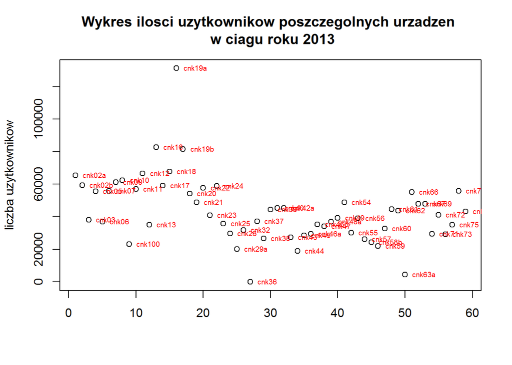

```r
dane %>% group_by(device) %>% mutate( suma = sum(count)) %>% filter(row_number() == 1) %>%
   select(device,suma) -> df_suma_urzadzenia

plot(df_suma_urzadzenia$suma, main = "Wykres ilosci uzytkownikow poszczegolnych urzadzen \n w ciagu roku 2013",
     xlab="", ylab="liczba uzytkownikow")
text(df_suma_urzadzenia$suma,df_suma_urzadzenia$device, row.names(mtcars), cex=0.6, pos=4, col="red")
```

```r
summary(df_suma_urzadzenia$suma)
```

```
##    Min. 1st Qu.  Median    Mean 3rd Qu.    Max.
##      24   29940   40880   43490   55710  131100
```

##### Z wykresu i podsumowania widac że

1. mamy 2 obserwacje o wyjatkowo niskiej liczbie uzytkownikow (cnk36 i cnk 63a) - zbadamy powod takiej sytuacji
2. po wykluczeniu tych 2 obserwacji najnizsza liczba uzytkownikow charakteryzuje sie cnk44, a najwyzsza cnk19a - przyjrzymy sie tym 2 urzadzeniom blizej
3. wiekszosc obserwacji wpada w pas od 20 000 unikalnych uzytkownikow w ciagu roku do 60 000 uzytkownikow - mediana dla wszystkich danych wynosi 40 880, a srednia 43 490 (podniesiona zapewne przez odstajaca obserwacje cnk19a)

```r
# 2 odstajace obserwacje z niskimi wartosciami

cat("suma dla cnk36 - nazwa skryptu pythonowego: sociograms.py")
```

```
## suma dla cnk36 - nazwa skryptu pythonowego: sociograms.py
```

```r
dla_cnk36 <- df_suma_urzadzenia[df_suma_urzadzenia$device == c("cnk36"),]
dla_cnk36
```

```
## Source: local data frame [1 x 2]
## Groups: device [1]
##
##   device  suma
##    (chr) (int)
## 1  cnk36    24
```

```r
cat("przyjrzyjmy sie kiedy te urzadzenia byly uzytkowane")
```

```
## przyjrzyjmy sie kiedy te urzadzenia byly uzytkowane
```

```r
# odfiltrujemy wszystkie daty, w ktorych bylo to urzadzenie uzywane
dane %>% filter(device =="cnk36") %>% mutate(date = as.Date(paste("2013",month, day), format="%Y %b %e")) %>%
   select(date, count) -> df_cnk36
cat("liczba dni uzytkowania w ciagu roku")
```

```
## liczba dni uzytkowania w ciagu roku
```

```r
nrow(df_cnk36)
```

```
## [1] 9
```

```r
cat("urzadzenie bylo uzytkowane 9 dni w roku, przyjrzyjmy sie kiedy to bylo i czy rozklad liczby uzytkownikow jest rownomierny")
```

```
## urzadzenie bylo uzytkowane 9 dni w roku, przyjrzyjmy sie kiedy to bylo i czy rozklad liczby uzytkownikow jest rownomierny
```

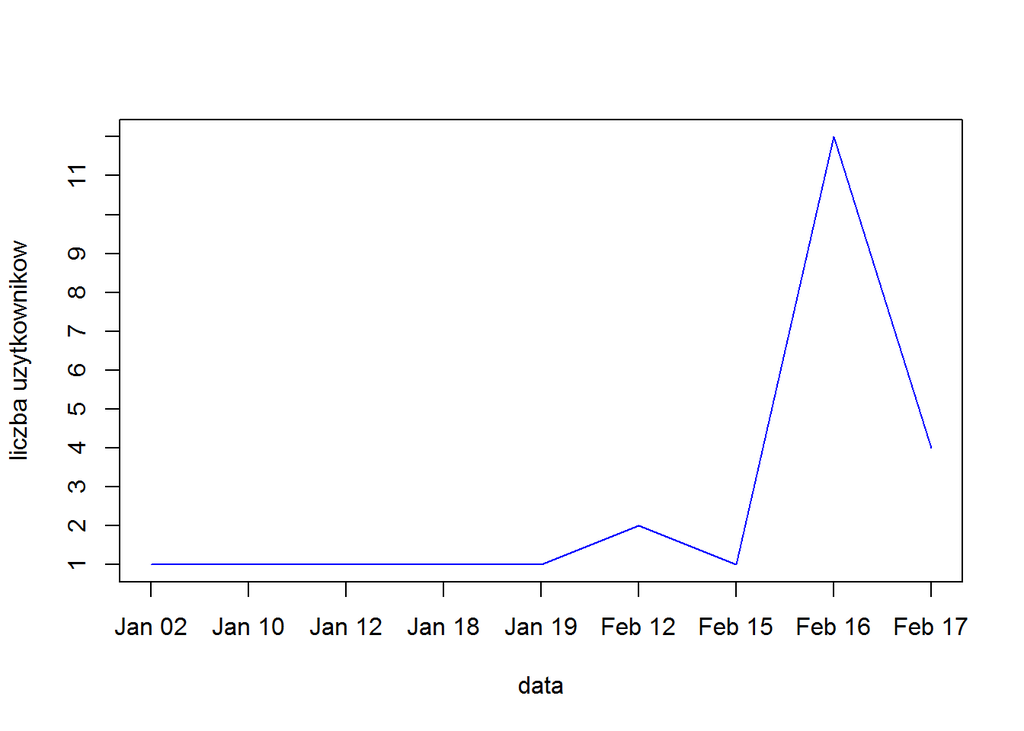

```r
plot(df_cnk36$count, xaxt="n", xlab="data", ylab="liczba uzytkownikow",yaxt="n",col="blue", pch=20, cex=3, type="l")
axis(2,at=1:12)
axis(1, at=1:nrow(df_cnk36), labels = format(df_cnk36$date,"%b %d"))
```

##### Jak widac poza 16 lutym 2013 (sobota), liczba uzytkownikow jest bardzo mala (moze warto spojrzec na ten dzien w innych analizach, dla malych liczb), urzadzenie bylo uzywane czesto 1-krotnie w ciagu dnia, a na przestrzeni calego roku, tylko pare dni w styczniu i lutym (wycofanie urzadzenia pozniej?, zmiana ustawien na brak rejestracji karty uzytkownika?)

##### To samo zrobmy dla cnk63a , skrypt: messagetoothercivilisations.py

```r
# suma dla cnk63a
dla_cnk63a <- df_suma_urzadzenia[df_suma_urzadzenia$device == c("cnk63a"),]
dla_cnk63a
```

```
## Source: local data frame [1 x 2]
## Groups: device [1]
##
##   device  suma
##    (chr) (int)
## 1 cnk63a  4533
```

```r
# przyjrzyjmy sie kiedy te urzadzenie bylo uzytkowane
# odfiltrujemy wszystkie daty, w ktorych bylo to urzadzenie uzywane
dane %>% filter(device =="cnk63a") %>% mutate(date = as.Date(paste("2013",month, day), format="%Y %b %e")) %>%
   select(date, count) %>% arrange(date) -> df_cnk63a
cat("liczba dni uzytkowania w ciagu roku")
```

```
## liczba dni uzytkowania w ciagu roku
```

```r
nrow(df_cnk63a)
```

```
## [1] 42
```

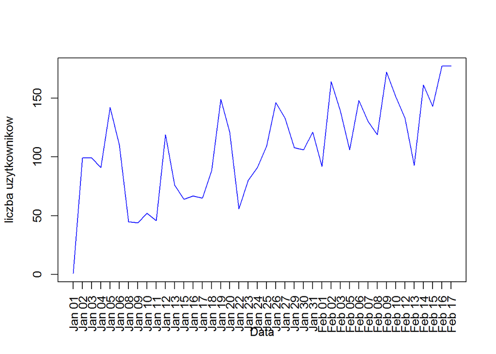

```r
# urzadzenie bylo uzytkowane 42 dni w roku, przyjrzyjmy sie kiedy to bylo i czy rozklad liczby uzytkownikow jest rownomierny

plot(df_cnk63a$count, xaxt="n", xlab="Data", ylab="liczba uzytkownikow", col="blue", pch=20, cex=3, type="l")
axis(1, at=1:nrow(df_cnk63a), labels = format(df_cnk63a$date,"%b %d"), las=2)
```

##### Jak widac urzadzenie bylo wykorzystywane tylko w dniach od 1 stycznia 2013 do 17 lutego 2013, przy czym ilosc uzytkownikow zwiekszala sie wraz z czasem.Warto zauwazyc ze co tydzien wystepowaly dwa dni zwiekszonej liczby uzytkownikow, tj w sob i w ndz, czego mozna bylo sie oczywiscie spodziewac.

##### Po wykluczeniu tych 2 obserwacji najnizsza liczba uzytkownikow charakteryzuje sie cnk44, a najwyzsza cnk19a - przyjrzymy sie tym 2 urzadzeniom blizej.

```r
# suma dla min tego bez odstających - cnk44 (migrations.py)
dla_cnk44 <- df_suma_urzadzenia[df_suma_urzadzenia$device == c("cnk44"),]
dla_cnk44
```

```
## Source: local data frame [1 x 2]
## Groups: device [1]
##
##   device  suma
##    (chr) (int)
## 1  cnk44 18969
```

```r
# przyjrzyjmy sie kiedy te urzadzenia byly uzytkowane

# odfiltrujemy wszystkie daty, w ktorych bylo to urzadzenie uzywane
dane %>% filter(device =="cnk44") %>% mutate(date = as.Date(paste("2013",month, day), format="%Y %b %e")) %>%
   select(date, count)  %>% arrange(date) -> df_cnk44

# liczba dni uzytkowania w ciagu roku
nrow(df_cnk44)
```

```
## [1] 306
```

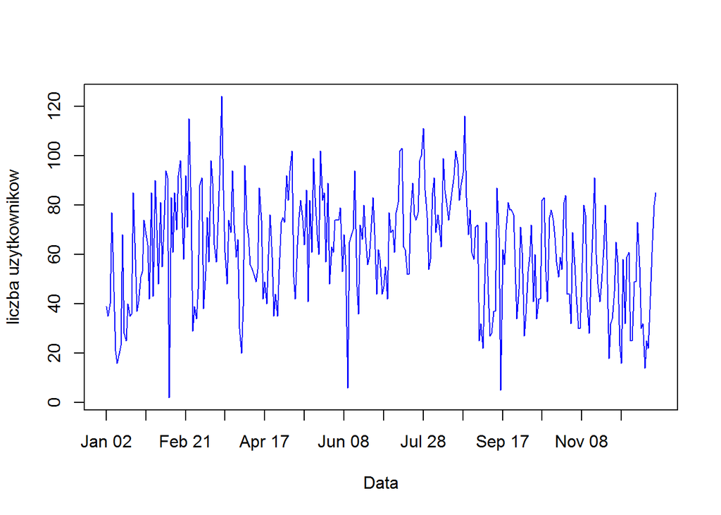

```r
#do etykiet
ile <- 14
co_ktora <- ceiling(nrow(df_cnk44)/ile)
etykiety <- df_cnk44$date[seq(1,nrow(df_cnk44),by = co_ktora)]

plot(df_cnk44$count, xlab="Data", xaxt='n',ylab="liczba uzytkownikow",col="blue", pch=20, cex=3, type="l")
axis(1, at=seq(1,nrow(df_cnk44),by = co_ktora), labels = format(etykiety,"%b %d"))
```

```r
summary(df_cnk44$count)
```

```
##    Min. 1st Qu.  Median    Mean 3rd Qu.    Max.
##    2.00   45.25   62.00   61.99   78.00  124.00
```

##### Maksymalna ilosc uzytkownikow dla cnk44 to 124, a te wartosci oscylowalu kolo 62 (srednia, mediana), zatem średnio ta maszyna jest słabo (rzecz względna) użytkowana przez rózne osoby w ciagu dnia.

##### Sprawdzmy w jakie dni tygodnia bylo najwiecej i najmniej uzytkownikow.

```r
head(df_cnk44[order(df_cnk44$count),],6)
```

```
##           date count
## 36  2013-02-11     2
## 220 2013-09-16     5
## 135 2013-06-10     6
## 300 2013-12-19    14
## 7   2013-01-09    16
## 287 2013-12-04    16
```

```r
maxy <- tail(df_cnk44[order(df_cnk44$count),],6)

weekdays(maxy$date)
```

```
## [1] "Sunday"   "Sunday"   "Sunday"   "Saturday" "Saturday" "Saturday"
```

```r
cat("3 najwieksze liczby sa 16 marca, 24 sierpnia i 23 lutego, są to weekendy")
```

```
## 3 najwieksze liczby sa 16 marca, 24 sierpnia i 23 lutego, są to weekendy
```

```r
# suma dla MAX z wszystkich urzadzen - cnk19a (clientstresseffects.py)

dla_cnk19a <- df_suma_urzadzenia[df_suma_urzadzenia$device == c("cnk19a"),]
dla_cnk19a
```

```
## Source: local data frame [1 x 2]
## Groups: device [1]
##
##   device   suma
##    (chr)  (int)
## 1 cnk19a 131096
```

```r
# przyjrzyjmy sie kiedy te urzadzenie byly uzytkowane

# odfiltrujemy wszystkie daty, w ktorych bylo to urzadzenie uzywane
dane %>% filter(device =="cnk19a") %>% mutate(date = as.Date(paste("2013",month, day), format="%Y %b %e")) %>%
   select(date, count)  %>% arrange(date) -> df_cnk19a

# liczba dni uzytkowania w ciagu roku
nrow(df_cnk19a)
```

```
## [1] 308
```

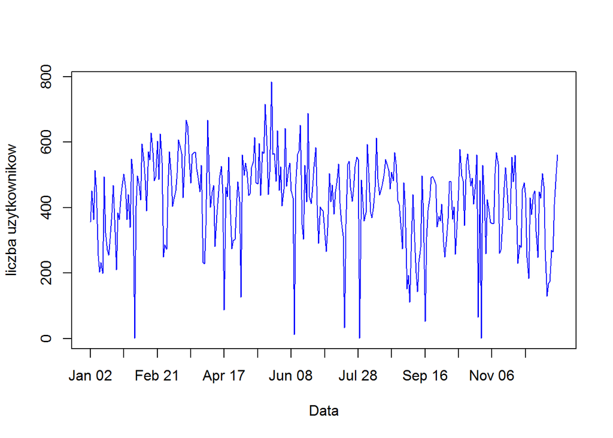

```r
# urzadzenie bylo uzytkowane 308 dni w roku, przyjrzyjmy sie kiedy to bylo i czy rozklad liczby
# uzytkownikow jest rownomierny

ile <- 14
co_ktora <- ceiling(nrow(df_cnk19a)/ile)
etykiety <- df_cnk19a$date[seq(1,nrow(df_cnk19a),by = co_ktora)]

plot(df_cnk19a$count, xlab="Data", xaxt='n',ylab="liczba uzytkownikow",col="blue", pch=20, cex=3, type="l")
axis(1, at=seq(1,nrow(df_cnk19a),by = co_ktora), labels = format(etykiety,"%b %d"))
```

```r
summary(df_cnk19a$count)
```

```
##    Min. 1st Qu.  Median    Mean 3rd Qu.    Max.
##     1.0   358.8   448.5   425.6   511.8   784.0
```

##### Maksymalna ilosc uzytkownikow dla cnk19a (tej max) to 784, a te wartsci oscylowalu kolo 440 (srednia - 425.6, mediana - 448.5), zatem średnio ta maszyna jet często (rzecz względna) użytkowana przez rózne osoby w ciagu dnia.

```r
miny <- head(df_cnk19a[order(df_cnk19a$count),],6)

# dni o malej liczbie uzytkownikow
weekdays(miny$date) # w pon małe liczebnosci (zamkniete cnk)
```

```
## [1] "Monday"   "Monday"   "Monday"   "Monday"   "Thursday" "Monday"
```

```r
maxy <- tail(df_cnk44[order(df_cnk44$count),],6)

# dni o duxej liczbie uzytkownikow
weekdays(maxy$date) # w weekendy najwiecej osob
```

```
## [1] "Sunday"   "Sunday"   "Sunday"   "Saturday" "Saturday" "Saturday"
```

```r
library(stringi)

sciezka_raportu_calosc <- file.path(sciezka_zapisu,paste("calosc_unikalne.csv", sep=""))

dane <- read.csv(sciezka_raportu_calosc, stringsAsFactors = F, sep=",", header=T)
dane1 <- dane[,-4]
dane1 <- dane1[!duplicated(dane1), ]

#dane %>% group_by(visitor) %>% mutate( count = n()) %>% filter(row_number() == 1) -> aj

dane1 %>% group_by(month, day) %>% mutate( count = n()) %>% filter(row_number() == 1) %>%
   mutate(date = as.Date(paste("2013",month, day), format="%Y %b %e")) %>%
   select(- visitor) -> df_suma_dni

# porzadkuje wg dat
df_suma_dni <- df_suma_dni[order(df_suma_dni$date),]

# laczna suma unikalnych uzytkownikow (traktowana jako w danym dniu kazda karta to 1 osoba tylko) wyniosla
sum(df_suma_dni$count)
```

```
## [1] 307654
```

```r
summary(df_suma_dni$count)
```

```
##    Min. 1st Qu.  Median    Mean 3rd Qu.    Max.
##     1.0   787.0  1015.0   946.6  1171.0  2085.0
```

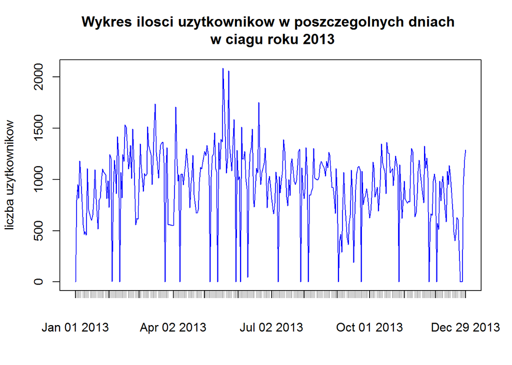

```r
# min liczba uzytkownikow w jednym dniu to 1, a max 2085.

library(xts)
razem.xts <- xts(df_suma_dni$count, df_suma_dni$date)
plot.xts(razem.xts, auto.grid = F, type="l",main = "Wykres ilosci uzytkownikow w poszczegolnych dniach \n w ciagu roku 2013",
         xlab="", ylab="liczba uzytkownikow")
lines(razem.xts, col = "blue")
```

```r
#porzadkuje wg liczby uzytkownikow

#niepopularne dni:
df_suma_dni <- df_suma_dni[order(df_suma_dni$count),]
dni_min <- table(weekdays(head(df_suma_dni,50)$date))
dni_min
```

```
##
##    Friday    Monday    Sunday  Thursday   Tuesday Wednesday
##         2        17         1         9        12         9
```

```r
#popularne dni:
dni_max <- table(weekdays(tail(df_suma_dni,50)$date))
dni_max
```

```
##
##    Friday  Saturday    Sunday  Thursday   Tuesday Wednesday
##        10        16         9         9         3         3
```

```r
#UWAGI:
#laczna liczba odwiedzajacych w 2013 wyniosla tutaj lekko ponad 300 tys. co nie jest zgodne z rzeczywistoscia (oficjalne wyniki mowia o ponad milionie) - zastanowic sie gdzie jest blad w przetwarzaniu
```